# HW3

Author

Shuchen Wu

## Question 1

```r
# install.packages("tidytext")
library(tidyverse)
library(tidytext)

pubmed = read.csv("pubmed.csv", header = TRUE)

dim(pubmed)
```

```
[1] 3241    2
```

```r
abstract_count_by_term = pubmed |>
  count(term, sort = TRUE)

abstract_count_by_term
```

```
             term   n
1           covid 981
2 prostate cancer 787
3    preeclampsia 780
4 cystic fibrosis 376
5      meningitis 317
```

```r
pubmed_tokens = pubmed |>
  unnest_tokens(token, abstract)

head(pubmed_tokens)
```

```
   term      token
1 covid background
2 covid        and
3 covid       aims
4 covid       many
5 covid   patients
6 covid       with
```

```r
token_count_all = pubmed_tokens |>
  count(token, sort = TRUE)

head(token_count_all, 10)
```

```
   token     n
1    the 28126
2     of 24760
3    and 19993
4     in 14653
5     to 10920
6      a  8245
7   with  8038
8  covid  7275
9     19  7080
10    is  5649
```

```r
top5_tokens_by_term = pubmed_tokens |>
  count(term, token, sort = TRUE) |>
  group_by(term) |>
  slice_max(order_by = n, n = 5, with_ties = FALSE) |>
  arrange(term, desc(n))

top5_tokens_by_term
```

```
# A tibble: 25 × 3
# Groups:   term [5]
   term            token     n
   <chr>           <chr> <int>
 1 covid           the    9741
 2 covid           of     7668
 3 covid           covid  7275
 4 covid           19     7035
 5 covid           and    6861
 6 cystic fibrosis the    2677
 7 cystic fibrosis of     2304
 8 cystic fibrosis and    1777
 9 cystic fibrosis in     1497
10 cystic fibrosis to     1011
# ℹ 15 more rows
```

There are 3,241 abstracts in the dataset across five search terms. There are 981 abstracts associated with covid, 787 with prostate cancer, 780 with preeclampsia, 376 with cystic fibrosis, and 317 with meningitis.

After tokenizing the abstracts, I counted token frequencies overall and within each search term. I found that the most common tokens overall are mostly common English words such as “the” (28126), “of” (24760), and “and”(19993). This is interesting because it shows that raw token counts are heavily affected by stop words. For the covid term, “covid” and “19” are also among the most common tokens, which reflects the topic directly. Overall, the top 5 tokens for each search term are useful for a first summary, but they are not always the most informative words unless stop words are removed.

For covid, the 5 most common tokens are “the” (9741), “of” (7668), “covid” (7275), “19” (7035), and “and” (6861).

For cystic fibrosis, the 5 most common tokens are “the” (2677), “of” (2304), “and” (1777), “in” (1497), and “to” (1011).

For meningitis, the 5 most common tokens are “the” (2489), “of” (2269), “and” (1683), “in” (1322), and “a” (830).

For preeclampsia, the 5 most common tokens are “the” (7119), “of” (6837), “and” (5255), “in” (3869), and “to” (2651).

For prostate cancer, the 5 most common tokens are “the” (6100), “of” (5682), “and” (4417), “cancer” (3840), and “prostate” (3832).

## Question 2

```r
data("stop_words")

pubmed_tokens_nostop = pubmed |>
  unnest_tokens(token, abstract) |>
  anti_join(stop_words, by = c("token" = "word"))

head(pubmed_tokens_nostop)
```

```
   term       token
1 covid  background
2 covid        aims
3 covid    patients
4 covid coronavirus
5 covid     disease
6 covid        2019
```

```r
token_count_nostop = pubmed_tokens_nostop |>
  count(token, sort = TRUE)

head(token_count_nostop, 10)
```

```
          token    n
1         covid 7275
2            19 7080
3      patients 4674
4        cancer 3999
5      prostate 3832
6       disease 2574
7           pre 2165
8     eclampsia 2005
9  preeclampsia 1863
10    treatment 1841
```

```r
top5_tokens_nostop_by_term = pubmed_tokens_nostop |>
  count(term, token, sort = TRUE) |>
  group_by(term) |>
  slice_max(order_by = n, n = 5, with_ties = FALSE) |>
  arrange(term, desc(n))

top5_tokens_nostop_by_term
```

```
# A tibble: 25 × 3
# Groups:   term [5]
   term            token        n
   <chr>           <chr>    <int>
 1 covid           covid     7275
 2 covid           19        7035
 3 covid           patients  2293
 4 covid           disease    943
 5 covid           pandemic   800
 6 cystic fibrosis fibrosis   867
 7 cystic fibrosis cystic     862
 8 cystic fibrosis cf         625
 9 cystic fibrosis patients   586
10 cystic fibrosis disease    400
# ℹ 15 more rows
```

Yes, removing stop words changes which tokens appear as the most frequent. Before removing stop words, the most common tokens were mostly common English words such as “the,” “of,” and “and.” After removing stop words, the most frequent tokens become much more topic-specific and easier to interpret.

After removing stop words, the 5 most common tokens for covid are “covid” (7275), “19” (7035), “patients” (2293), “disease” (943), and “pandemic” (800).

For cystic fibrosis, the 5 most common tokens are “fibrosis” (867), “cystic” (862), “cf” (625), “patients” (586), and “disease” (400).

For meningitis, the 5 most common tokens are “patients” (446), “meningitis” (429), “meningeal” (219), “csf” (206), and “clinical” (187).

For preeclampsia, the 5 most common tokens are “pre” (2038), “eclampsia” (2005), “preeclampsia” (1863), “women” (1196), and “pregnancy” (969).

For prostate cancer, the 5 most common tokens are “cancer” (3840), “prostate” (3832), “patients” (934), “treatment” (926), and “disease” (652).

Overall, removing stop words makes the results much more informative because the most frequent tokens now reflect the actual medical topics in the abstracts rather than general English words. One interesting pattern is that some terms remain split during tokenization, such as “19” for covid and “pre” plus “eclampsia” for preeclampsia, which suggests that tokenization can separate meaningful multi-part terms.

## Question 3

```r
library(forcats)

# tokenize into bigrams
pubmed_bigrams = pubmed |>
  unnest_ngrams(bigram, abstract, n = 2)

head(pubmed_bigrams)
```

```
   term           bigram
1 covid   background and
2 covid         and aims
3 covid        aims many
4 covid    many patients
5 covid    patients with
6 covid with coronavirus
```

```r
# count bigrams
bigram_count = pubmed_bigrams |>
  count(bigram, sort = TRUE)

# top 10 most common bigrams
top10_bigrams = bigram_count |>
  slice_max(order_by = n, n = 10, with_ties = FALSE)

top10_bigrams
```

```
            bigram    n
1         covid 19 6969
2           of the 3883
3           in the 3418
4  prostate cancer 3222
5    pre eclampsia 1854
6    patients with 1587
7         of covid 1519
8          and the 1154
9           to the 1061
10     of prostate  870
```

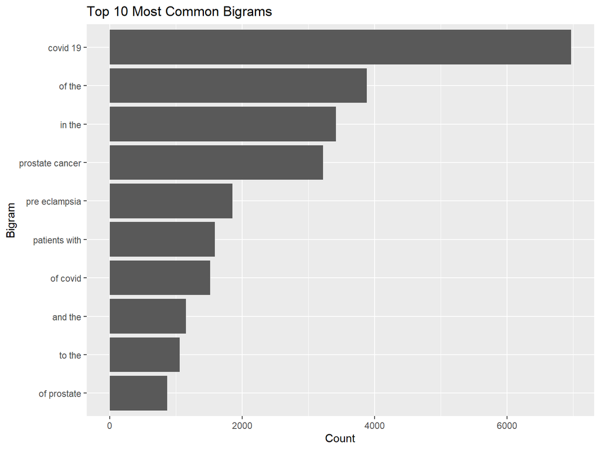

```r
# visualize
top10_bigrams |>
  ggplot(aes(x = n, y = fct_reorder(bigram, n))) +
  geom_col() +
  labs(
    title = "Top 10 Most Common Bigrams",
    x = "Count",
    y = "Bigram"
  )
```

I tokenize the abstracts into bigrams, and found that the 10 most common bigrams are “covid 19,” “of the,” “in the,” “prostate cancer,” “pre eclampsia,” “patients with,” “of covid,” “and the,” “to the,” and “of prostate.” The most frequent bigram is “covid 19,” which is consistent with the large number of covid abstracts. However, several common bigrams are still generic English phrases, showing that the results are affected by stop words when no filtering is applied.

## Question 4

```r
# count each token within each search term
tfidf_tbl = pubmed_tokens |>
  count(term, token, sort = TRUE) |>
  bind_tf_idf(token, term, n)

head(tfidf_tbl, 10)
```

```
              term token    n         tf      idf     tf_idf
1            covid   the 9741 0.04968098 0.000000 0.00000000
2            covid    of 7668 0.03910828 0.000000 0.00000000
3            covid covid 7275 0.03710391 1.609438 0.05971643
4     preeclampsia   the 7119 0.05069430 0.000000 0.00000000
5            covid    19 7035 0.03587986 0.000000 0.00000000
6            covid   and 6861 0.03499243 0.000000 0.00000000
7     preeclampsia    of 6837 0.04868618 0.000000 0.00000000
8  prostate cancer   the 6100 0.04964799 0.000000 0.00000000
9  prostate cancer    of 5682 0.04624588 0.000000 0.00000000
10    preeclampsia   and 5255 0.03742078 0.000000 0.00000000
```

```r
# top 5 tokens with highest TF-IDF for each search term
top5_tfidf_by_term = tfidf_tbl |>
  group_by(term) |>
  slice_max(order_by = tf_idf, n = 5, with_ties = FALSE) |>
  arrange(term, desc(tf_idf))

top5_tfidf_by_term
```

```
# A tibble: 25 × 6
# Groups:   term [5]
   term            token           n      tf   idf  tf_idf
   <chr>           <chr>       <int>   <dbl> <dbl>   <dbl>
 1 covid           covid        7275 0.0371  1.61  0.0597
 2 covid           pandemic      800 0.00408 1.61  0.00657
 3 covid           coronavirus   647 0.00330 1.61  0.00531
 4 covid           sars          372 0.00190 1.61  0.00305
 5 covid           cov           334 0.00170 1.61  0.00274
 6 cystic fibrosis cf            625 0.0127  0.916 0.0117
 7 cystic fibrosis fibrosis      867 0.0176  0.511 0.00901
 8 cystic fibrosis cystic        862 0.0175  0.511 0.00896
 9 cystic fibrosis cftr           86 0.00175 1.61  0.00282
10 cystic fibrosis sweat          83 0.00169 1.61  0.00272
# ℹ 15 more rows
```

TF-IDF was calculated for each token-search term combination, treating each search term as a document. The tokens with the highest TF-IDF values are those that are relatively frequent within one search term but less common across the other search terms.

For covid, the 5 tokens with the highest TF-IDF values are “covid,” “pandemic,” “coronavirus,” “sars,” and “cov.”

For cystic fibrosis, the 5 tokens with the highest TF-IDF values are “cf,” “fibrosis,” “cystic,” “cftr,” and “sweat.”

For meningitis, the 5 tokens with the highest TF-IDF values are “meningitis,” “meningeal,” “pachymeningitis,” “csf,” and “meninges.”

For preeclampsia, the 5 tokens with the highest TF-IDF values are “eclampsia,” “preeclampsia,” “pregnancy,” “maternal,” and “gestational.”

For prostate cancer, the 5 tokens with the highest TF-IDF values are “prostate,” “androgen,” “psa,” “prostatectomy,” and “castration.”

These results are different from the answers in Question 1 because Question 1 only identified the most frequent tokens within each search term, so many common English words such as “the,” “of,” and “and” appeared at the top. In contrast, TF-IDF downweights words that are common across all search terms and highlights words that are more distinctive to a specific topic. As a result, the TF-IDF results are much more informative and more specific to each medical subject.

## Question 5

```r
# install.packages("textdata")
library(textdata)

# tokenize and join NRC lexicon
pubmed_nrc = pubmed |>
  unnest_tokens(word, abstract) |>
  inner_join(get_sentiments("nrc"), by = "word")

head(pubmed_nrc)
```

```
   term    word sentiment
1 covid disease     anger
2 covid disease   disgust
3 covid disease      fear
4 covid disease  negative
5 covid disease   sadness
6 covid disease     anger
```

```r
# most common sentiment for each search term
most_common_sentiment = pubmed_nrc |>
  group_by(term) |>
  summarise(sentiment = names(which.max(table(sentiment))))

most_common_sentiment
```

```
# A tibble: 5 × 2
  term            sentiment
  <chr>           <chr>
1 covid           positive
2 cystic fibrosis positive
3 meningitis      negative
4 preeclampsia    positive
5 prostate cancer negative
```

```r
nrc_fun = get_sentiments("nrc")
nrc_fun = nrc_fun[!nrc_fun$sentiment %in% c("positive", "negative"), ]

pubmed_nrc_no_pn = pubmed |>
  unnest_tokens(word, abstract) |>
  inner_join(nrc_fun, by = "word")

most_common_sentiment_no_pn = pubmed_nrc_no_pn |>
  group_by(term) |>
  summarise(sentiment = names(which.max(table(sentiment))))

most_common_sentiment_no_pn
```

```
# A tibble: 5 × 2
  term            sentiment
  <chr>           <chr>
1 covid           fear
2 cystic fibrosis disgust
3 meningitis      fear
4 preeclampsia    anticipation
5 prostate cancer fear
```

Using the NRC lexicon, the most common sentiment is positive for covid, cystic fibrosis, and preeclampsia, and negative for meningitis and prostate cancer. After removing positive and negative, the most common sentiment becomes fear for covid, meningitis, and prostate cancer, disgust for cystic fibrosis, and anticipation for preeclampsia. This shows that positive and negative dominate the original NRC results, while removing makes the sentiment analysis more nuanced and interpretable.

## Question 6

```r
# create an index for abstracts
pubmed_id = pubmed |>
  mutate(abstract_id = row_number())

# average AFINN score for each abstract
afinn_by_abstract = pubmed_id |>
  unnest_tokens(word, abstract) |>
  inner_join(get_sentiments("afinn"), by = "word") |>
  group_by(term, abstract_id) |>
  summarise(avg_score = mean(value), .groups = "drop")

head(afinn_by_abstract, 10)
```

```
# A tibble: 10 × 3
   term  abstract_id avg_score
   <chr>       <int>     <dbl>
 1 covid           1    -1.13
 2 covid           2    -2
 3 covid           3     0.214
 4 covid           4    -0.8
 5 covid           5    -1.67
 6 covid           6    -0.143
 7 covid           7     0.167
 8 covid           8     0.909
 9 covid           9    -0.222
10 covid          10    -1.62
```

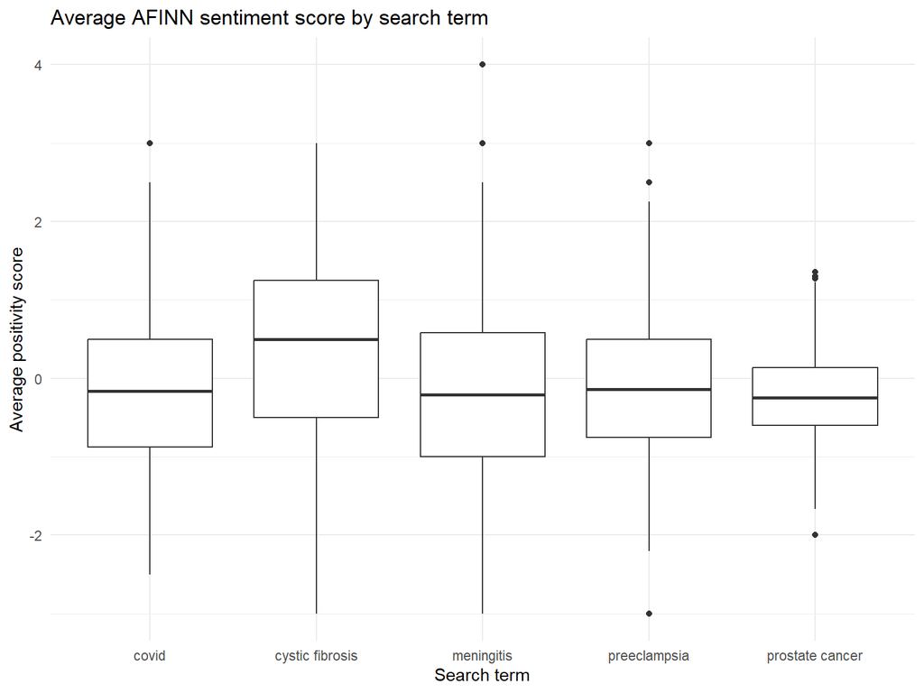

```r
ggplot(afinn_by_abstract, aes(x = term, y = avg_score)) +
  geom_boxplot() +
  labs(
    title = "Average AFINN sentiment score by search term",
    x = "Search term",
    y = "Average positivity score"
  ) +
  theme_minimal()
```